# Notas de Clase: Componentes principales I

¿Un solo indicador o cinco? El encargo de la institución que asigna tutorías

Estadística Multidimensional · Universidad Distrital Francisco José de Caldas

Sábado 17 de octubre de 2026

# 1 Introducción: el encargo

Hoy no llegamos como estudiantes de estadística. **Llegamos como analistas con un cliente.**

El cliente es **una institución de educación técnica** que recibe cada semestre los resultados de la prueba Saber de sus estudiantes. Tiene plata para un programa de **tutorías** y quiere repartirla bien. Su coordinadora académica nos escribe:

> *«Recibo cinco puntajes por estudiante y no tengo tiempo de mirar cinco listas. ¿Puedo asignar las tutorías con un solo número, el puntaje global? ¿O me estoy perdiendo a alguien?»*

Ésa es la pregunta de hoy, y es una pregunta de negocio:

> **¿Cuánta información se pierde al resumir cinco puntajes en uno solo, y a quién deja por fuera esa pérdida?**

La herramienta para responderla se llama **análisis de componentes principales**. Pero antes del nombre va la idea, y la idea es sencilla: *buscar el mejor resumen posible de los cinco módulos y medir qué se queda por fuera.*

# 2 Objetivos de aprendizaje

Al terminar la sesión, cada estudiante debe poder:

1. Explicar **por qué cinco puntajes que se mueven juntos se pueden resumir** en menos.
2. Decir **en palabras** qué es una componente: una suma con pesos de las variables originales.
3. Leer **cuánta información guarda** cada componente y decidir cuántas conservar.
4. Leer **los pesos** de una componente y decir qué mide.
5. **Traducir el resultado a una decisión del cliente**: qué se reporta, qué se pierde y a quién afecta.

# 3 La base con la que llegamos

Repetimos la limpieza de las dos sesiones pasadas, para que estas notas tejan solas.

```r
saber <- read.csv("PruebaSaber1.csv", sep = ";", fileEncoding = "latin1",
                  stringsAsFactors = FALSE)

s <- saber |>
  transmute(
    cuantitativo = MOD_RAZONA_CUANTITAT_PUNT,
    lectura      = MOD_LECTURA_CRITICA_PUNT,
    ciudadanas   = MOD_COMPETEN_CIUDADA_PUNT,
    ingles       = MOD_INGLES_PUNT,
    escritura    = MOD_COMUNI_ESCRITA_PUNT,
    global       = PUNT_GLOBAL,
    estrato      = FAMI_ESTRATOVIVIENDA
  )
s$id <- seq_len(nrow(s))

modulos <- c("cuantitativo", "lectura", "ciudadanas", "ingles", "escritura")
etiqueta <- c(cuantitativo = "cuantitativo", lectura = "lectura", ciudadanas = "ciudadanas",
              ingles = "inglés", escritura = "escritura")

# 1. la fila corrida una columna (sesión 1)
s <- s[s$estrato != "Empleado obrero u operario", ]
# 2. los 26 ceros de inglés: no presentaron el módulo (sesión 1)
s$ingles[s$ingles == 0] <- NA
# 3. filas 671 y 614: ceros en módulos que no presentaron (sesión 2)
for (m in modulos) s[[m]][s$id %in% c(671, 614) & s[[m]] == 0] <- NA

sc <- s[complete.cases(s[modulos]), ]
c(en_la_base = nrow(s), con_los_cinco = nrow(sc))
```

```
##    en_la_base con_los_cinco
##          9999          9907
```

Trabajamos con los 9 907 estudiantes que tienen los cinco módulos. Igual que en la sesión pasada, los que no los tienen se reportan aparte: **un resumen de cinco puntajes no se puede calcular con un hueco.**

# 4 Primero: ¿los cinco módulos dicen lo mismo?

Si los cinco puntajes fueran independientes —si saber uno no dijera nada de los otros—, no habría forma de resumirlos: cada uno traería información que los demás no tienen. **Se pueden resumir porque se repiten.** Veamos cuánto.

```r
R <- cor(sc[modulos])
round(R, 2)
```

```
##              cuantitativo lectura ciudadanas ingles escritura
## cuantitativo         1.00    0.56       0.47   0.40      0.25
## lectura              0.56    1.00       0.64   0.43      0.31
## ciudadanas           0.47    0.64       1.00   0.40      0.30
## ingles               0.40    0.43       0.40   1.00      0.23
## escritura            0.25    0.31       0.30   0.23      1.00
```

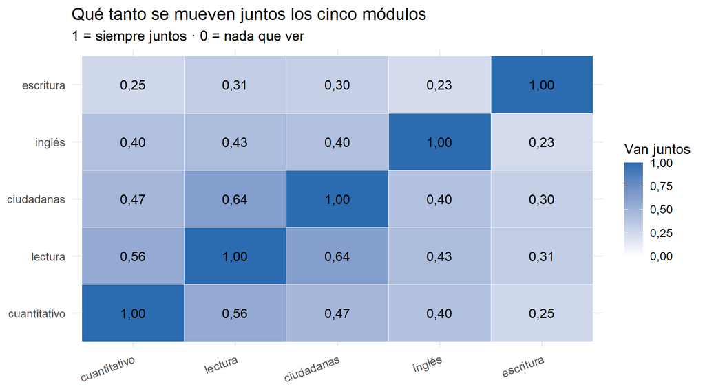

```r
as.data.frame(as.table(R)) |>
  mutate(Var1 = factor(etiqueta[as.character(Var1)], levels = etiqueta),
         Var2 = factor(etiqueta[as.character(Var2)], levels = etiqueta)) |>
  ggplot(aes(Var1, Var2, fill = Freq)) +
  geom_tile(color = "white") +
  geom_text(aes(label = coma(Freq, 2)), size = 4.2) +
  scale_fill_gradient(low = "white", high = "#2B6CB0", limits = c(0, 1), name = "Van juntos",
                      labels = function(x) coma(x, 2)) +
  labs(title = "Qué tanto se mueven juntos los cinco módulos",
       subtitle = "1 = siempre juntos · 0 = nada que ver", x = NULL, y = NULL) +
  theme(axis.text.x = element_text(angle = 20, hjust = 1))
```

> 📋 **Describir:** todos los módulos se mueven juntos, pero no por igual. La pareja más unida es lectura con ciudadanas (0,64). La más suelta es **escritura**: con ningún módulo pasa de 0,31.

> 🔎 **Analizar:** hay una parte que se repite —a quien le va bien en uno le suele ir bien en los demás— y **eso es lo que permite resumir**. Pero escritura va más sola que el resto: si la resumimos junto con los otros, algo de ella se va a perder. **Decisión:** vale la pena buscar un resumen, y hay que vigilar qué le pasa a escritura.

# 5 La idea: el mejor resumen posible

## 5.1 Un resumen es una suma con pesos

El puntaje global ya es un resumen: es, más o menos, el promedio de los cinco módulos. Un promedio es una suma con **pesos iguales**. La pregunta es si hay **otros pesos** que resuman mejor.

> 📐 **La matemática, enunciada.** Una **componente** es una suma con pesos de los cinco módulos:

> $$C = w_1\,\text{cuantitativo} +
> w_2\,\text{lectura} + w_3\,\text{ciudadanas} + w_4\,\text{inglés} +
> w_5\,\text{escritura}$$

> con la condición $w_1^2 + w_2^2 + w_3^2 + w_4^2 + w_5^2 = 1$, para que los pesos no crezcan sin límite.

> **En palabras:** la primera componente es la suma con pesos que **más separa a los estudiantes entre sí**. Si un resumen deja a todo el mundo en el mismo número, no sirve para decidir; el mejor resumen es el que más diferencia a unos de otros. Esa diferencia se mide con la **varianza**, y la varianza es **información**.

## 5.2 Lo que encuentra R

```r
pca <- prcomp(sc[modulos])          # los cinco ya están en la misma escala
pesos <- pca$rotation
round(pesos[, 1:3], 3)
```

```
##                PC1    PC2    PC3
## cuantitativo 0.465  0.227 -0.160
## lectura      0.517  0.125 -0.279
## ciudadanas   0.497  0.087 -0.341
## ingles       0.410  0.208  0.879
## escritura    0.318 -0.939  0.087
```

```r
c(peso_mas_bajo_en_la_1   = round(min(pesos[, 1]), 3),
  peso_mas_alto_en_la_1   = round(max(pesos[, 1]), 3),
  la_1_va_con_el_global   = round(abs(cor(pca$x[, 1], sc$global)), 3))
```

```
## peso_mas_bajo_en_la_1 peso_mas_alto_en_la_1 la_1_va_con_el_global
##                 0.318                 0.517                 0.996
```

> 📋 **Describir:** en la primera componente los cinco pesos tienen el mismo signo y son parecidos, entre 0,32 y 0,52. Escritura es la que menos pesa. Y esa componente va con el puntaje global 0,996: son prácticamente lo mismo.

> 🔎 **Analizar:** **el mejor resumen de un solo número es, en la práctica, el puntaje global.** La institución no se equivocaba: si va a usar un solo número, el global es el correcto. Pero la pregunta del cliente no era cuál número usar, sino **qué se pierde**. **Decisión:** ahora hay que medir cuánta información guarda ese número y cuánta deja por fuera.

# 6 ¿Cuánta información guarda cada componente?

Los cinco módulos tienen, entre todos, una cantidad de información: la suma de sus varianzas. Las componentes **no crean ni destruyen información: la reparten**.

> 📐 **La matemática, enunciada.** Si $\lambda_1, \dots, \lambda_5$ son las varianzas de las cinco componentes,

> $$\lambda_1 + \lambda_2 + \lambda_3 +
> \lambda_4 + \lambda_5 = \text{var}(\text{cuant}) +
> \text{var}(\text{lect}) + \dots + \text{var}(\text{escr})$$

> **En palabras:** la información total no cambia; la primera componente se queda con la mayor tajada, la segunda con la mayor tajada de lo que sobra, y así. La proporción $\lambda_1 / (\lambda_1 + \dots + \lambda_5)$ es **qué parte de la información guarda la primera**.

```r
lambda <- pca$sdev^2
c(suma_varianzas_modulos     = round(sum(sapply(sc[modulos], var)), 1),
  suma_varianzas_componentes = round(sum(lambda), 1))
```

```
##     suma_varianzas_modulos suma_varianzas_componentes
##                     2012.6                     2012.6
```

```r
reparto <- data.frame(componente = paste0("C", 1:5),
                      de_cada_100 = 100 * lambda / sum(lambda),
                      acumulado   = 100 * cumsum(lambda) / sum(lambda))
reparto$de_cada_100 <- round(reparto$de_cada_100, 1)
reparto$acumulado   <- round(reparto$acumulado, 1)
reparto
```

| componente | de_cada_100 | acumulado |
| --- | --- | --- |
| C1 | 52.9 | 52.9 |
| C2 | 16.2 | 69.1 |
| C3 | 13.0 | 82.1 |
| C4 | 10.9 | 93.0 |
| C5 | 7.0 | 100.0 |

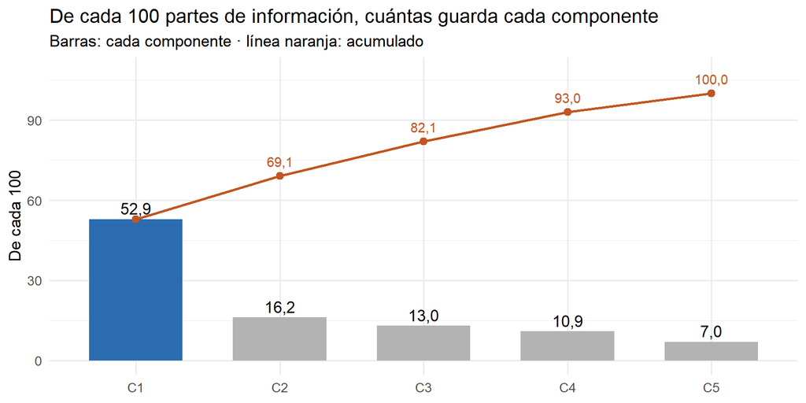

```r
ggplot(reparto, aes(componente, de_cada_100)) +
  geom_col(fill = c("#2B6CB0", rep("grey70", 4)), width = 0.65) +
  geom_text(aes(label = coma(de_cada_100)), vjust = -0.4, size = 4.5) +
  geom_line(aes(y = acumulado, group = 1), color = "#C05621", linewidth = 1) +
  geom_point(aes(y = acumulado), color = "#C05621", size = 2.5) +
  geom_text(data = reparto[-1, ], aes(y = acumulado, label = coma(acumulado)), vjust = -0.9, color = "#C05621", size = 3.8) +
  scale_y_continuous(limits = c(0, 108)) +
  labs(title = "De cada 100 partes de información, cuántas guarda cada componente",
       subtitle = "Barras: cada componente · línea naranja: acumulado",
       x = NULL, y = "De cada 100")
```

> 📋 **Describir:** la primera componente guarda 52,9 de cada 100 partes de la información de los cinco módulos. Con dos se llega a 69,1, y con tres a 82,1.

> 🔎 **Analizar:** un solo número guarda **un poco más de la mitad**. Es mucho para un solo número, pero **casi la mitad de lo que dicen los cinco puntajes se queda por fuera**. La pregunta de negocio no es si 53 es mucho o poco en abstracto: es **si lo que se queda por fuera le importa al cliente.** **Decisión:** hay que mirar qué es esa información que no entra en el global.

# 7 ¿Qué mide cada componente?

Los pesos dicen qué mide cada componente. Un peso grande —positivo o negativo— es un módulo que manda.

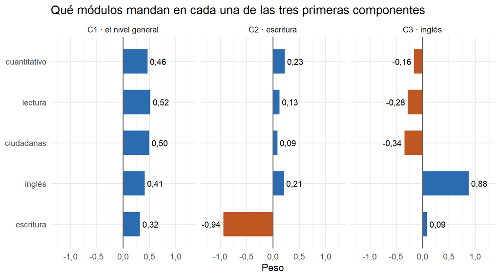

```r
data.frame(pesos[, 1:3], modulo = rownames(pesos)) |>
  pivot_longer(-modulo, names_to = "componente", values_to = "peso") |>
  mutate(componente = recode(componente, PC1 = "C1 · el nivel general",
                             PC2 = "C2 · escritura", PC3 = "C3 · inglés"),
         modulo = factor(etiqueta[modulo], levels = rev(etiqueta))) |>
  ggplot(aes(peso, modulo, fill = peso > 0)) +
  geom_col(width = 0.6) +
  geom_vline(xintercept = 0, color = "grey40") +
  geom_text(aes(label = coma(peso, 2), hjust = ifelse(peso > 0, -0.15, 1.15)), size = 3.8) +
  facet_wrap(~ componente) +
  scale_fill_manual(values = c("#C05621", "#2B6CB0"), guide = "none") +
  scale_x_continuous(limits = c(-1.25, 1.25), labels = function(x) coma(x, 1)) +
  labs(title = "Qué módulos mandan en cada una de las tres primeras componentes",
       x = "Peso", y = NULL)
```

> 📋 **Describir:** en la primera, todos los módulos pesan parecido y en la misma dirección. En la segunda, escritura pesa 0,94 (con signo contrario al resto) y los demás casi nada. En la tercera, inglés pesa 0,88.

> 🔎 **Analizar:** la primera es **el nivel general del estudiante**: sube cuando sube todo. La segunda es **escritura por su cuenta**: distingue a los que escriben mejor o peor de lo que haría esperar su nivel general. La tercera es lo mismo con **inglés**. Es decir: lo que el global deja por fuera **no es ruido, tiene nombre**: son escritura e inglés, justo los dos módulos que menos se parecen a los demás. **Decisión:** si el cliente da tutorías de escritura o de inglés, el global no le sirve para escoger a quién.

> ⚠️ El signo de una componente es arbitrario: R pudo haber entregado todos los pesos con el signo contrario y sería la misma componente. Lo que se lee es **qué módulos pesan mucho** y **si van en la misma dirección o en contra**.

# 8 El costo de decidir con un solo número

Hasta aquí todo está en «partes de información». Al cliente eso no le dice nada. **Lo traducimos a estudiantes.**

Supongamos que la institución da tutoría al 20 % más bajo. Puede escoger a ese 20 % de dos maneras: por el puntaje global, o por el módulo de la tutoría.

```r
bajo <- function(v) v <= quantile(v, 0.20)
cobertura <- lapply(c("escritura", "ingles", "cuantitativo"), function(m) {
  necesita <- bajo(sc[[m]]); detecta <- bajo(sc$global)
  data.frame(tutoria = m,
             lo_necesitan = sum(necesita),
             el_global_los_ve = sum(necesita & detecta),
             se_quedan_por_fuera = sum(necesita & !detecta))
}) |> bind_rows()
cobertura$de_cada_100_por_fuera <- round(100 * cobertura$se_quedan_por_fuera / cobertura$lo_necesitan, 1)
cobertura
```

| tutoria | lo_necesitan | el_global_los_ve | se_quedan_por_fuera | de_cada_100_por_fuera |
| --- | --- | --- | --- | --- |
| escritura | 2097 | 1129 | 968 | 46.2 |
| ingles | 2014 | 1066 | 948 | 47.1 |
| cuantitativo | 2013 | 1270 | 743 | 36.9 |

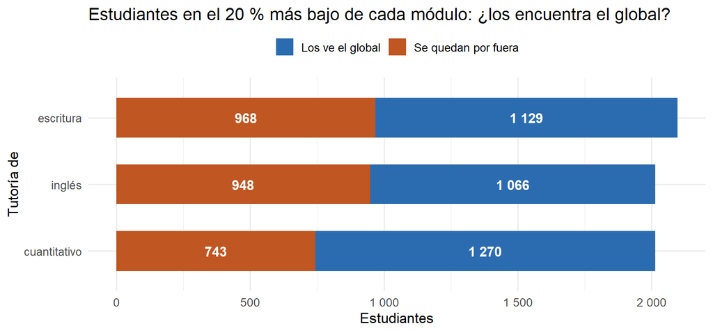

```r
cobertura |>
  select(tutoria, `Los ve el global` = el_global_los_ve, `Se quedan por fuera` = se_quedan_por_fuera) |>
  pivot_longer(-tutoria) |>
  mutate(tutoria = factor(etiqueta[tutoria], levels = rev(etiqueta[c("escritura", "ingles", "cuantitativo")]))) |>
  ggplot(aes(value, tutoria, fill = name)) +
  geom_col(width = 0.6) +
  geom_text(aes(label = miles(value)), position = position_stack(vjust = 0.5), color = "white",
            fontface = "bold", size = 4.3) +
  scale_fill_manual(values = c("#2B6CB0", "#C05621"), name = NULL) +
  scale_x_continuous(labels = miles) +
  labs(title = "Estudiantes en el 20 % más bajo de cada módulo: ¿los encuentra el global?",
       x = "Estudiantes", y = "Tutoría de") +
  theme(legend.position = "top")
```

> 📋 **Describir:** 2 097 estudiantes están en el 20 % más bajo de escritura. Si la tutoría se asigna por el global, **968 de ellos se quedan sin tutoría**: 46,2 de cada 100. En inglés se quedan por fuera 948. En cuantitativo, que pesa más en el global, 743.

> 🔎 **Analizar:** **ésa es la información que se pierde, con nombre y apellido.** El global funciona para el nivel general, pero casi la mitad de los que escriben peor no se ven, porque su nivel general es aceptable. Y el costo es más alto justo en los módulos que la componente principal pesa menos. **Decisión:** para el cliente, un número sirve para ordenar; para asignar tutorías de un área, hay que mirar el módulo de esa área.

```r
disparejos <- sc$global >= mean(sc$global) & bajo(sc$escritura)
c(global_sobre_el_promedio_y_escritura_en_el_20_bajo = sum(disparejos))
```

```
## global_sobre_el_promedio_y_escritura_en_el_20_bajo
##                                                338
```

> 📋 **Describir:** 338 estudiantes tienen el global **por encima del promedio** y la escritura en el 20 % más bajo.

> 🔎 **Analizar:** para la institución, ésos son estudiantes «sin problema» si mira solo el global. Son el tipo de estudiante que la segunda componente separa. **Decisión:** es la lista que se le entrega al programa de escritura, y ningún resumen de un solo número la produce.

# 9 ¿Hay que estandarizar antes?

Una decisión técnica que sí cambia resultados: si las variables están en escalas distintas, la que tenga números más grandes se come la componente. **Aquí no pasa**, porque los cinco módulos están en la misma escala.

```r
pca_est <- prcomp(sc[modulos], scale. = TRUE)
c(sin_estandarizar_la_1_guarda = round(100 * lambda[1] / sum(lambda), 1),
  estandarizando_la_1_guarda   = round(100 * pca_est$sdev[1]^2 / sum(pca_est$sdev^2), 1),
  desviacion_menor = round(min(sapply(sc[modulos], sd)), 1),
  desviacion_mayor = round(max(sapply(sc[modulos], sd)), 1))
```

```
## sin_estandarizar_la_1_guarda   estandarizando_la_1_guarda
##                         52.9                         52.8
##             desviacion_menor             desviacion_mayor
##                         20.0                         20.2
```

> 📋 **Describir:** los cinco módulos tienen desviaciones entre 20,0 y 20,2, y la primera componente guarda casi lo mismo con o sin estandarizar.

> 🔎 **Analizar:** estandarizar es poner a todas las variables a desviación 1 antes de resumir. Aquí los cinco ya tienen la misma desviación, así que el resultado casi no cambia. **Decisión:** en Saber no hace falta. **En su dataset casi seguro sí:** si mezclan pesos con años o con porcentajes, sin estandarizar la componente solo repite la variable de números más grandes. En R es `prcomp(datos, scale. = TRUE)`.

# 10 Qué no es una componente

- **No es una causa.** Que la primera componente sea «el nivel general» no dice que exista una habilidad general que produce los cinco puntajes. Dice que los puntajes se mueven juntos.
- **No es un nombre que la técnica pone.** «Nivel general», «escritura», «inglés» son nombres que **nosotros** pusimos mirando los pesos. Otro analista podría nombrarlas distinto, y habría que discutirlo con el cliente.
- **No reemplaza a los datos.** Es un resumen: sirve para ordenar y para ver qué se pierde, no para borrar las variables originales.

# 11 La puerta a lo que viene

| Lo que vimos hoy | La pregunta que queda | Dónde se responde |
| --- | --- | --- |
| El nivel general guarda un poco más de la mitad | Si pongo a los estudiantes en un plano con las dos primeras componentes, **¿qué perfiles aparecen?** | **Lun 19 oct** · PCA II y biplot |
| Los nombres de las componentes los pusimos nosotros | ¿Hay **habilidades** detrás de los puntajes, una cuantitativa y otra verbal? | **Sáb 24 oct** · Análisis factorial |

# 12 Actividad práctica

Con **el dataset de su equipo** y **el cliente de su caso de negocio**:

1. **La matriz de correlaciones.** ¿Qué variables se repiten? ¿Cuál va más sola?
2. **El PCA.** Corran `prcomp()` sobre sus variables numéricas. **Decidan primero si estandarizan** y digan por qué.
3. **El reparto.** ¿Cuánta información guarda la primera componente? ¿Cuántas hacen falta para pasar de 80 de cada 100?
4. **Los pesos.** Pónganle nombre a las dos primeras componentes mirando sus pesos.
5. **El costo para su cliente.** Si su cliente decidiera con un solo número, ¿a quién o a qué dejaría por fuera? Cuéntenlo.

# 13 Preguntas conceptuales

1. ¿Por qué cinco puntajes que se mueven juntos se pueden resumir, y cinco puntajes independientes no?
2. La primera componente guarda 53 de cada 100 partes de la información. ¿Es mucho o poco? ¿De qué depende la respuesta?
3. Si la primera componente va con el global casi exactamente, ¿para qué sirvió calcularla?
4. ¿Por qué escritura aparece sola en la segunda componente? Relaciónelo con la matriz de correlaciones.
5. Un equipo tiene en su base el precio en pesos y la calificación de 1 a 5. Corre el PCA sin estandarizar y la primera componente guarda 99 de cada 100. ¿Qué pasó?
6. ¿Cuál de estas afirmaciones es correcta? **(a)** La primera componente demuestra que existe una habilidad general. **(b)** La primera componente es la suma con pesos que más separa a los estudiantes. **(c)** Las componentes eliminan la información que no sirve. **(d)** El signo de los pesos dice si un módulo es bueno o malo.

# 14 Conclusión: lo que le entregamos al cliente

A la coordinadora le respondemos en cuatro frases:

- **Sí, puede usar un solo número, y el correcto es el global.** Es prácticamente el mejor resumen posible de los cinco módulos.
- **Pero ese número guarda un poco más de la mitad de la información.** Lo que deja por fuera no es ruido: son escritura e inglés, los dos módulos que menos se parecen a los demás.
- **En estudiantes, el costo es concreto:** casi la mitad de los que más necesitan tutoría de escritura, y casi la mitad de los de inglés, no aparecen en la lista del global.
- **La decisión:** el global para ordenar y reportar; **escritura e inglés revisados aparte** para asignar las tutorías de esas áreas.

La técnica de hoy tiene nombre —**análisis de componentes principales**—, pero lo que hicimos fue contestar una pregunta de negocio: *qué se pierde al resumir, y a quién.*

# 15 Próxima clase

**Lunes 19 de octubre · Componentes principales II: el biplot.**

La pregunta: *si pongo a cada estudiante en un plano con el nivel general y con escritura, ¿qué perfiles aparecen, y a quién le sirve cada tipo de tutoría?* Veremos primero con **iris** un caso donde los grupos sí se separan, para comparar.